# Principes et M ́ethodes Statistiques TP 2019

CHECCHIN Olivier

BEGUINET Hugo

TIOUR Zaineb

# Analyse des defauts de cuves

## Question 1:

```r
#Loading the data :

cuves <- read.table("cuves.csv",sep=";",header=T)
#help("read.table")
#help(attach)
attach(cuves)

#Removing the NA data :
cuves <- cuves[!is.na(cuves)]
cuve1 <- cuve1[!is.na(cuve1)]
cuve2 <- cuve2[!is.na(cuve2)]
cuve3 <- cuve3[!is.na(cuve3)]
```

```r
#Reading the data
cuves
```

```
##  [1] 2.007 4.440 2.086 2.428 2.057 2.107 2.190 2.325 3.950 2.551 2.284
## [12] 2.373 2.464 2.261 2.408 2.910 2.775 3.551 3.643 2.017 2.767 2.334
## [23] 2.699 3.163 2.748 5.404 2.601 2.970 6.416 2.217 3.698 2.536 2.006
## [34] 2.207 2.222 2.591 2.889 2.236 5.437 2.406 2.498 3.643 2.185 2.661
## [45] 2.281 2.237 2.362 2.512 2.139 2.745 2.026 2.035 2.821 2.102 2.319
## [56] 2.059 3.270 2.438 3.070 2.451 3.134 2.551 2.781 3.029 2.863 2.638
## [67] 3.770 2.103 3.334 2.660 2.229 3.100 2.673 2.782 2.720 2.449 2.800
## [78] 3.197 2.662 2.840 2.738 3.722 2.921
```

```r
#cuve1
#cuve2
#cuve3

#Length of the data-vector :
n<-length(cuves)
n
```

```
## [1] 83
```

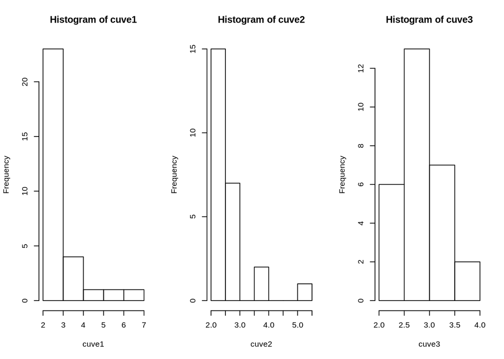

```r
#Histogram of the data using the default setting of R
par(mfcol=c(1,3))
hist(cuve1)
hist(cuve2)
hist(cuve3)
```

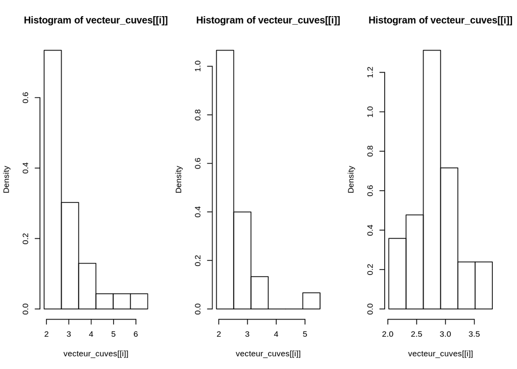

```r
# Histogramme classes de meme largeur :
# La régle de Sturges donne k = 6 classes.
k = 6
vecteur_cuves <- list(cuve1, cuve2, cuve3)
par(mfcol=c(1,3))
for(i in seq(1,3)){
  #Sorting the data
  Sorted_data <- sort(vecteur_cuves[[i]])
  Sorted_data
  #Length of the data-vector :
  n<-length(vecteur_cuves[[i]])
  n
  # Calcul des bornes inférieure et supérieure.
  a0 <-Sorted_data[1]-0.025*(Sorted_data[n]-Sorted_data[1])
  a6 <-Sorted_data[n]+0.025*(Sorted_data[n]-Sorted_data[1])
  a0
  a6
  # Largeur des classes
  h<-(a6-a0)/6
  h
  # Bornes des classes : on partage [a0,a6] en 6 intervalles
  # de largeur h.
  bornes <- seq(a0,a6,h)
  bornes
  hist(vecteur_cuves[[i]], probability = T, breaks = bornes)
}
```

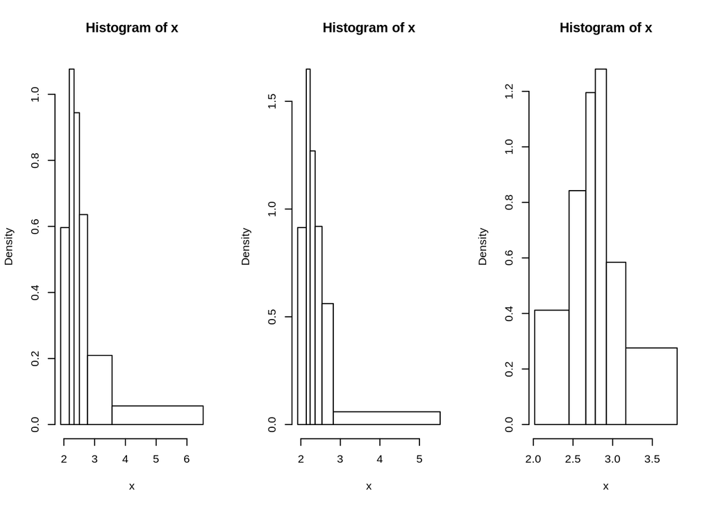

```r
histoeff <- function(x, xlim=NULL, ...)
{
  sx <- sort(x)
  n <- length(x)
  k <- round(log(n)/log(2)+1)
  rangex <- max(x)-min(x)
  breaks <- c(min(x)-0.025*rangex, quantile(x, seq(1, k-1)/k), max(x)+0.025*rangex)
  col <- 0
  if (is.null(xlim)) xlim<-c(breaks[1], breaks[k+1])
  hist(x, breaks=breaks, col=col, xlim=xlim, probability=T, ...)
}

#plotting the functions on the same window

par(mfcol=c(1,3))
for(i in seq(1,3)){
histoeff(vecteur_cuves[[i]])
}
```

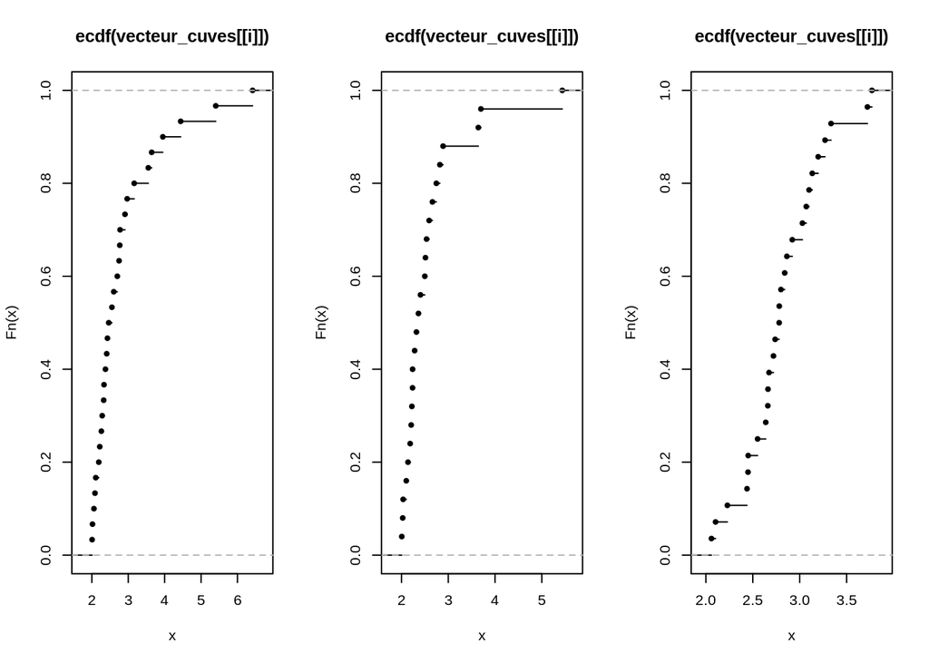

```r
#Ploting the emperical distribution function:
par(mfcol=c(1,3))
for(i in seq(1,3)){
plot(ecdf(vecteur_cuves[[i]]))
}
```

```r
#Indicators :
    #cuve 1 :
    summary(vecteur_cuves[[1]])
```

```
##    Min. 1st Qu.  Median    Mean 3rd Qu.    Max.
##   2.007   2.267   2.507   2.872   2.955   6.416
```

```r
    var(vecteur_cuves[[1]])
```

```
## [1] 1.046943
```

```r
    #cuve2
    summary(vecteur_cuves[[2]])
```

```
##    Min. 1st Qu.  Median    Mean 3rd Qu.    Max.
##   2.006   2.207   2.362   2.592   2.661   5.437
```

```r
    var(vecteur_cuves[[2]])
```

```
## [1] 0.5412769
```

```r
    #cuve3
    summary(vecteur_cuves[[3]])
```

```
##    Min. 1st Qu.  Median    Mean 3rd Qu.    Max.
##   2.059   2.616   2.781   2.821   3.078   3.770
```

```r
    var(vecteur_cuves[[3]])
```

```
## [1] 0.1733518
```

Avec cette étude de statistique descriptive, il semble que les fissures des cuves 1 et 2 suivent approximativement la meme loi qui nous est pour l’instant inconnue. Ce n’est pas le cas de la cuve 3 pour laquelle les fissures semblent suivre une loi complètement différente, plus proche de la loi normale.

## Question 2:

Calculons la fonction de répartition de la loi $\mathbb{P}(a,2)$.

Soit $x \in \mathbb{R}$.

$\mathbb{F}(x)=\int_{-\infty}^{x} f(t) dt = \int_{-\infty}^{x} \dfrac{a \times 2^a}{2^{1+a}} \times 1_{[2,+\infty[} (t) dt =a \times 2^a \int_{2}^{x} \dfrac{1}{t^{1+a}} dt = \dfrac{a \times 2^a}{-a} \left[ \dfrac{1}{t^a} \right]_{2}^{x} = -2^a \left[ \dfrac{1}{x^a} - \dfrac{1}{2^a} \right]$.

Donc $\mathbb{F}(x)=1-\left(\dfrac{2}{x} \right)^a$.

Calculons l’espérance de la loi $\mathbb{P}(a,2)$ :

Soit $B \in \mathbb{R}^+$.

$$\begin{eqnarray*}
\mathbb{E}(x) &=& \int_{-B}^{+B} tf(t) dt =
\int_{-B}^{+B} t \times \dfrac{a \times 2^a}{2^{1+a}} \times 1_{[2,+\infty[} (t) dt
=a \times 2^a\int_{2}^{+B} \dfrac{1}{t^a} dt
= \dfrac{a \times 2^a}{1-a} \left[ \dfrac{1}{t^{a-1}} \right]_{2}^{+B} \\
&=& \dfrac{2a}{1-a} \left( \dfrac{2}{B} \right)^{a-1} - \dfrac{2a}{1-a}.
\end{eqnarray*}$$

L’espérance sera finie si $a >1$.

Calculons la variance de la loi
$$\mathbb{P}(a,2)$$
.

$$\begin{eqnarray*}
\mathbb{V}(x) &=& \int_{-B}^{+B} t^2f(t) dt =
\int_{-B}^{+B} t^2 \times \dfrac{a2^a}{2^{1+a}} \times 1_{[2,+\infty[} (t) dt
=a \times 2^a\int_{2}^{+B} \dfrac{1}{t^{a-1}} dt
= \dfrac{a \times 2^a}{2-a} \left[ \dfrac{1}{t^{a-2}} \right]_{2}^{+B} \\
&=& \dfrac{4a}{2-a} \left( \dfrac{2}{B} \right)^{a-2} - \dfrac{4a}{2-a}.
\end{eqnarray*}$$

La variance sera finie si $a >2$.

Conclusion :

pour $a >2$; on a ;
$$\mathbb{E}(x)= - \frac{2a}{1-a}$$
,
$$\mathbb{V}(x)= -\frac{4a}{2-a}$$
et
$$\sigma(X) = \frac{2}{a-1} \sqrt{\frac{a}{a-2}}$$

## Question 3:

Pour trouver la loi de Y, on commence par calculer le fonction de repartition de loi de probabilité P(a,b) :

On a : $P(Y<y) = P(ln(\frac{X}{2})<y)$ $P(Y<y) = P(X<2 \exp(y))$

alors : $P(Y<y) = F(2 \exp(y))$

Si $y < 2$, alors $F(y)=0$, et si $2 \exp(y) < 2$ càd $y <0$ alors $F(2 \exp(y))=0$ sinon on a $P(Y<y) = 1 - (\frac{1}{\exp(y)})^a = 1 - \exp(-ay)$

Donc $Y$ suit une loi exponentielle de paramêtre $a$.

## Question 4:

Comme les observations sont indépendantes et de même loi on a d’après le théorème central limite:

$$\sqrt{n} \frac{\bar{Y}_n - E(Y)}{\sigma(Y)} \to \mathcal{N}(0,1)$$
Soit :

$$Z_n = \sqrt{n}\left(a\bar{Y}_n - 1\right)\to \mathcal{N}(0,1)$$

Maintenant qu’on a calculé notre fonction pivotale, il nous reste à l’exploiter pour trouver l’intervalle de confiance.

Par propriété de $Z_n$, on a:

$$P(\left|{Z_n}\right| < u_\alpha) =P\left(\left|\sqrt{n}\left(a\bar{Y}_n - 1\right)\right| < u_\alpha\right)= 1-\alpha$$

On doit donc résoudre l’inégalité suivante avec $T = \bar{Y}_n$:

$$\left|\sqrt{n}\left(aT - 1\right)\right| < u_\alpha$$
$$a^2 T^2 - 2aT + 1-\frac{u_\alpha^2}{n} \leq 0$$

Ce polynôme en $a$ n’est négatif qu’entre ses racines, d’où l’intervalle de confiance est:

$$\left[\frac{1-\frac{u_\alpha}{\sqrt{n}}}{T}; \frac{1+\frac{u_\alpha}{\sqrt{n}}}{T}\right]$$
On peut trouver un autre intervalle de confiance utilisant la fonction pivotale
$$2*a*n*\bar{Y_n}$$
qui suit une loi du chi2(2*n). En obtient alors l’intervalle de confiance bilatéral au seuil alpha pour a: Icc=
$$\left[\frac{z_{2n,\frac{alpha}{2}}}{2n\bar{Y_n}}; \frac{z_{2n,1-\frac{alpha}{2}}}{2n\bar{Y_n}}\right]$$

## Question 5:

1- On utilise tout d’abord la méthode graphique pour estimer la pertinance de la loi $P(a,2)$ . Pour vérifier si les données cuves suivent la loi $P(a,2)$ il suffit de vérifier si $Y = \ln(\frac{cuves}{2})$ suit la loi exponentielle de paramêtre $a$ (cf la question 3)

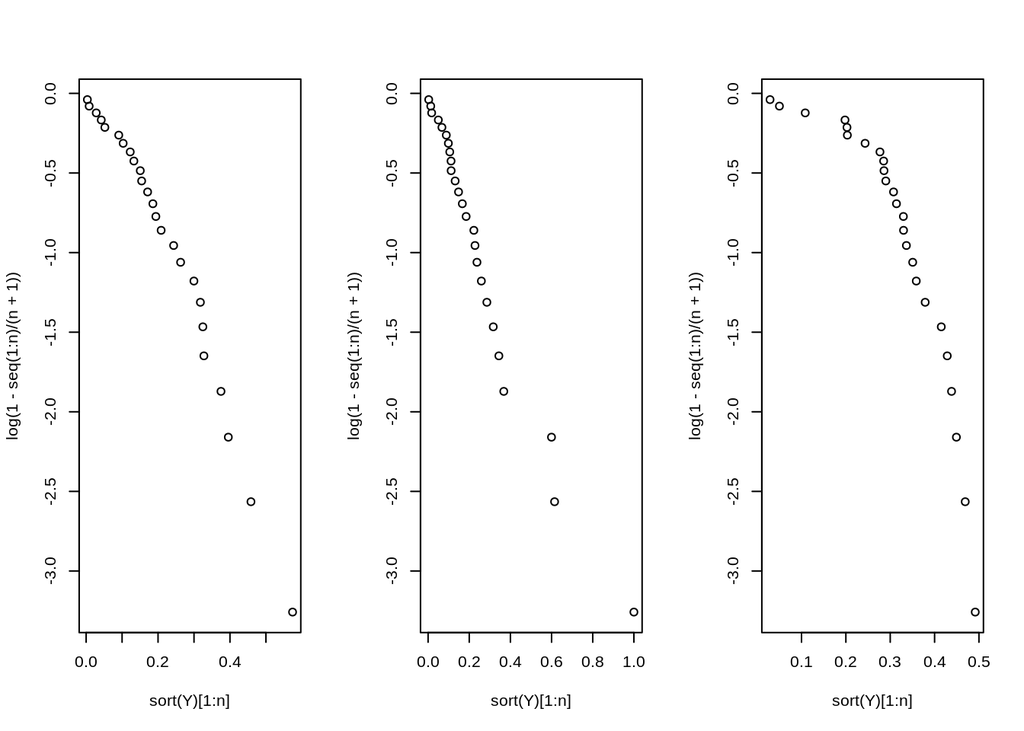

```r
n_1 <- length(vecteur_cuves[[1]])
n_2 <- length(vecteur_cuves[[2]])
n_3 <- length(vecteur_cuves[[3]])
n <- min(c(n_1,n_2, n_3))
par(mfcol=c(1,3))
for (i in seq(1,3)){
  cuve <- vecteur_cuves[[i]]
  Y <- log(cuve/2)
  # on vérifie Y suit la loi exponentielle
  plot(sort(Y)[1:n],log(1-seq(1:n)/(n+1)))
}
```

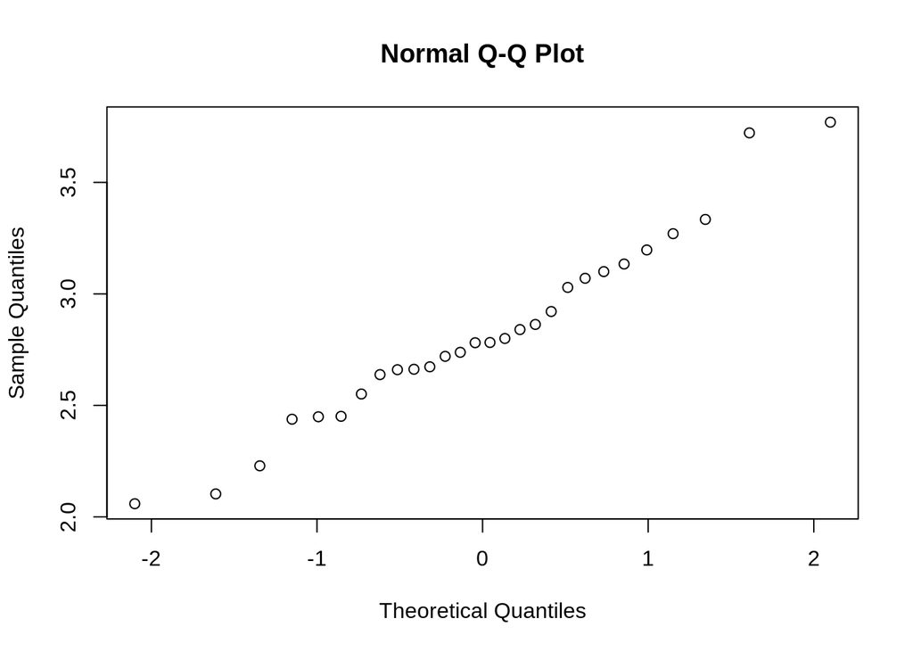

```r
qqnorm(cuve3)
```

2- Estimation du pramêtre $a$ :

Pour Y suivant une loi exp(a), on sait que l’EMM et l’EMV sont les mêmes.

-Estimateur du maximum de vraisemblance (EMV) :

Vu que $Y$ suit une loi exponentielle, on a
$$\hat{a_n} = \frac{1}{\bar{Y_n}}$$

```r
hat_a1_n <- 1/mean(log(cuve1/2))
hat_a1_n
```

```
## [1] 3.170032
```

```r
hat_a2_n <- 1/mean(log(cuve2/2))
hat_a2_n
```

```
## [1] 4.331652
```

```r
hat_a3_n <- 1/mean(log(cuve3/2))
hat_a3_n
```

```
## [1] 2.998926
```

-Qualité de l’estimateur :

$$E[\frac{1}{\bar{Y_n}}] = a \frac{n}{n-1}$$
On sait que l’EMV est asymptotiquement sans biais et efficace. Dans ce cas, il est biaisé. On considére donc $T_n = (n-1) \frac{1}{n \bar{Y_n}}$ comme notre nouvel estimateur sans biais On a alors notre meilleure estimation possible de a pour chaque cuve, même pour la 3 si l’on suppose que les fissures suivent une loi de Pa:

```r
T1_n=(n-1)*hat_a1_n/n
T2_n=(n-1)*hat_a2_n/n
T3_n=(n-1)*hat_a3_n/n
```

# Vérifications expérimentales à base de simulations :

## Question 1:

On sait simuler des données selon la loi exponentielle. On généralise la relation mise en avant précedemment: Y=ln(X/b) suit une loi exp(a), pour a et b fixés. On peut donc réussir à simuler des données selon la loi Pa(a,b).

```r
b=2

simu_echantillons_loi_exp=function(m,n,a){
  #m echantillons avec chaque echantillon simulant une population de n individus suivant la loi exp(a)
  echantillons_loi_exp=matrix(nrow = n, ncol=m)
  for(i in 1:m){
    donnees_loi_exp=rexp(n,rep(a,n))
    echantillons_loi_exp[,i]=donnees_loi_exp
  }
  return(echantillons_loi_exp)
}
```

## Question 2:

On va donc vérififer que l’intervalle de confiance mis en évidence précédemment “fonctionne” pour les données simulées. On veut donc que dans environ 95% des cas, la vrai valeur a appartienne à l’intervalle de confiance au seuil 5%.

```r
#seuil
alpha=5/100

pourcentage_appartenance_icc=function(echantillons_loi_exp,alpha,a,n,m){
  nb_appartenance=0
  for(i in 1:m){
    moy=mean(echantillons_loi_exp[,i])

    #bornes intervalle de confiance
    a_icc=qchisq(alpha/2,2*n)/(2*n*moy)
    b_icc=qchisq(1-alpha/2,2*n)/(2*n*moy)

    #booléen qui indique si le vrai parametre a appartient bien a l'icc
    a_in_icc= a>a_icc && a<b_icc

    #on ajoute 1 si a_in_icc est vrai
    nb_appartenance=nb_appartenance+a_in_icc
  }
  cat(nb_appartenance/m)
}

#on veut tester sur m echantillons de n individus, chacun suivant une loi exp(a)
n=1000
a=3
m=1000

#on simule donc les échantillons pour la loi exp(a), ce qui nous permet de les calculer pour la loi pa(a,b)
echantillons_loi_exp=simu_echantillons_loi_exp(m,n,a)
echantillons_loi_pa=b*exp(echantillons_loi_exp)

#on utilise les données suivant la loi exp(a) pour faciliter les calculs des icc
pourcentage_appartenance_icc(echantillons_loi_exp,alpha,a,n,m)
```

```
## 0.945
```

On vérifie bien que dans environ 95% des cas, la vrai valeur a appartient à l’intervalle de confiance.

## Question 3:

On veut comparer les performances des différents estimateurs. On en a deux: a_chapeau=1/moy(Yn) l’EMM et l’EMV qui est biaisé. a_chapeau_prime=(n-1)/(n*moy(Yn)) qui est non biaisé.

```r
#on veut tester sur m echantillons de n individus, chacun suivant une loi exp(a)
n=100
a=3
m=1000

#on simule donc les échantillons pour la loi exp(a)
echantillons_loi_exp=simu_echantillons_loi_exp(m,n,a)

#on calcule donc les différents estimateurs pour les m échantillons
a_chapeau=NULL
a_chapeau_prime=NULL
for(i in 1:m){
  a_chapeau[i]=1/mean(echantillons_loi_exp[,i])
  a_chapeau_prime[i]=(n-1)/(n*mean(echantillons_loi_exp[,i]))
}

#on calcule alors les biais et erreurs quadratiques
biais_a_chapeau=mean(a_chapeau)-a
biais_a_chapeau_prime=mean(a_chapeau_prime)-a

cat("biais a_chapeau:",biais_a_chapeau,"\n")
```

```
## biais a_chapeau: 0.04148352
```

```r
cat("biais a_chapeau_prime:",biais_a_chapeau_prime,"\n")
```

```
## biais a_chapeau_prime: 0.01106868
```

```r
erreur_quadratique_a_chapeau=mean((a_chapeau-a)**2)
erreur_quadratique_a_chapeau_prime=mean((a_chapeau_prime-a)**2)

cat("erreur quadratique a_chapeau:",erreur_quadratique_a_chapeau,"\n")
```

```
## erreur quadratique a_chapeau: 0.09866857
```

```r
cat("erreur quadratique a_chapeau_prime:",erreur_quadratique_a_chapeau_prime,"\n")
```

```
## erreur quadratique a_chapeau_prime: 0.09514095
```

On remarque que dans les deux cas, a_chapeau_prime est légèrement plus précis que a_chapeau. Plus n est grand, plus la différence entre les deux diminue et plus leur erreur quadratique est faible.

On en conclut que, comme on pouvait l’imaginer, l’estimateur sans biais a_chapeau_prime est le plus performant des deux.

## Question 4:

On veut vérifier que l’estimateur a_chapeau converge bien faiblement vers la valeur réelle de a.

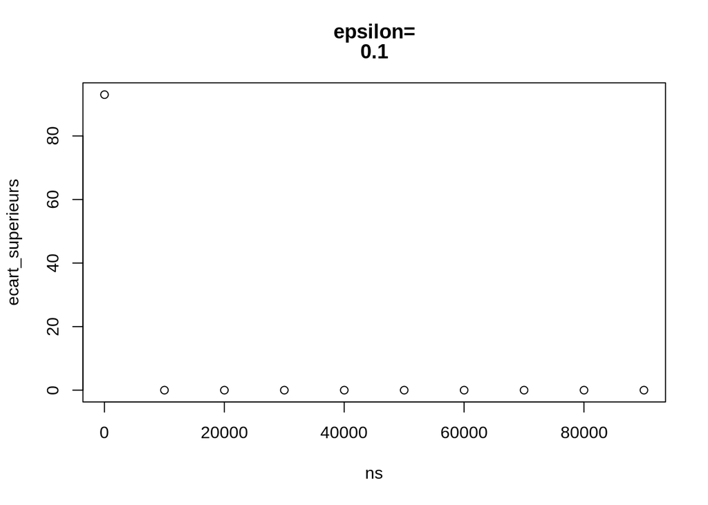

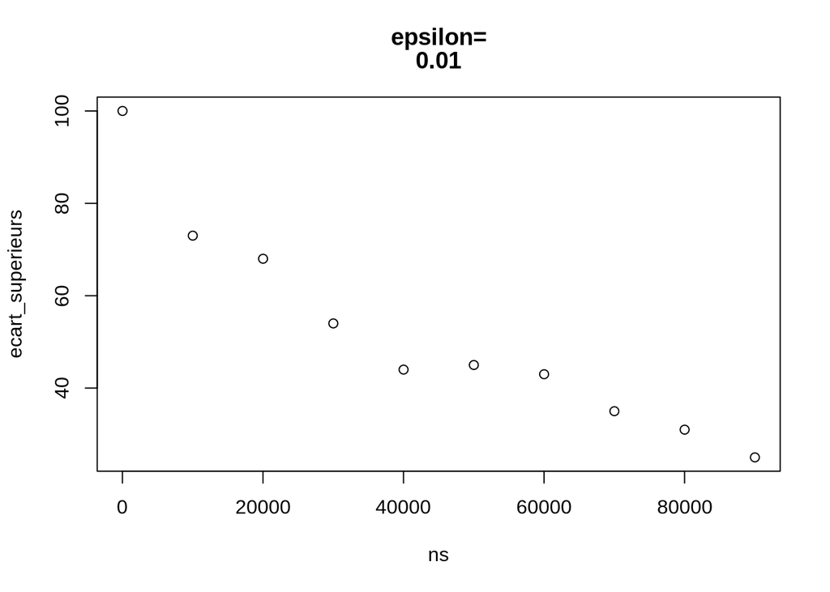

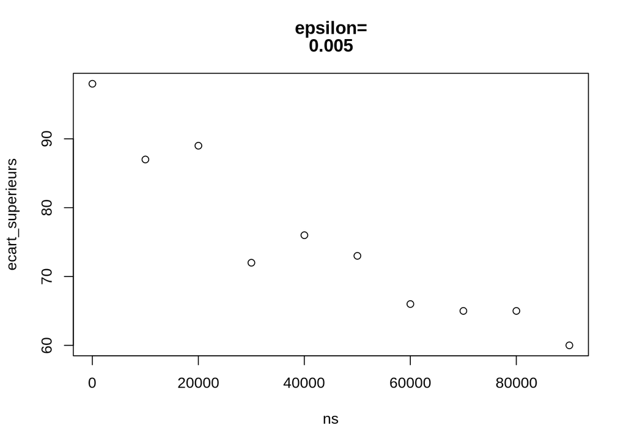

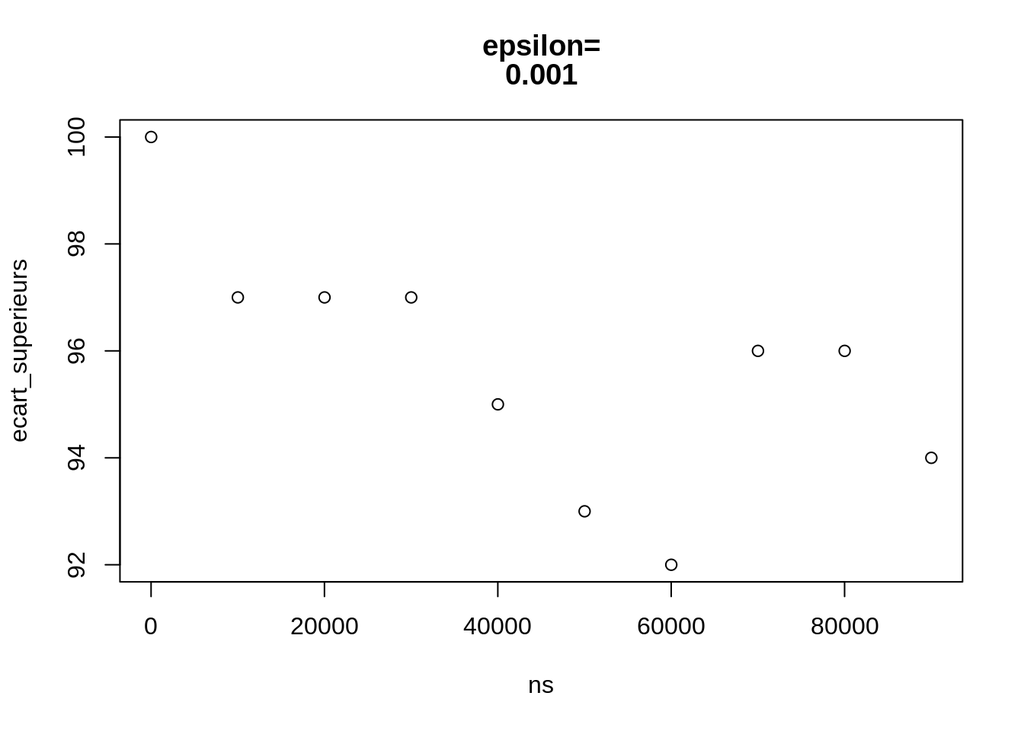

```r
#on va vérifier la convergence faible de a_chapeau, pour différents epsilons
epsilons=c(0.1,0.01,0.005,0.001)
ns=seq(10,100000,10000)
a=3
m=100

#pour chaque epsilon et pour chaque n, on va donc regarder combien d'estimateurs sur m ont un écart avec a supérieur à epsilon
for(epsilon in epsilons){
  ecart_superieurs=NULL
  for(n in ns){
    ecart_superieur=0
    echantillons_loi_exp=simu_echantillons_loi_exp(m,n,a)
    a_chapeau=NULL
    for(i in 1:m){
      a_chapeau[i]=1/mean(echantillons_loi_exp[,i])
      if(abs(a_chapeau[i]-a)>epsilon)
        ecart_superieur=ecart_superieur+1
    }
    ecart_superieurs=c(ecart_superieurs,ecart_superieur)
  }
  plot(ns,ecart_superieurs,main=c('epsilon=',epsilon))
}
```

## Question 5:

On veut vérifier que a_chapeau suit asymptotiquement(selon n) une loi normale.

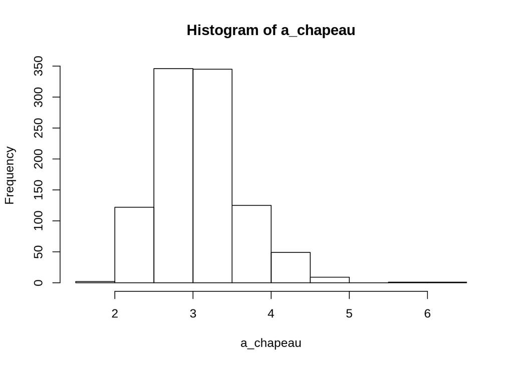

```r
#on veut tester sur m echantillons de n individus, chacun suivant une loi exp(a)
n=35
a=3
m=1000

#on simule donc les échantillons pour la loi exp(a)
echantillons_loi_exp=simu_echantillons_loi_exp(m,n,a)

a_chapeau=NULL
for(i in 1:m){
  a_chapeau[i]=1/mean(echantillons_loi_exp[,i])
}

hist(a_chapeau)
```

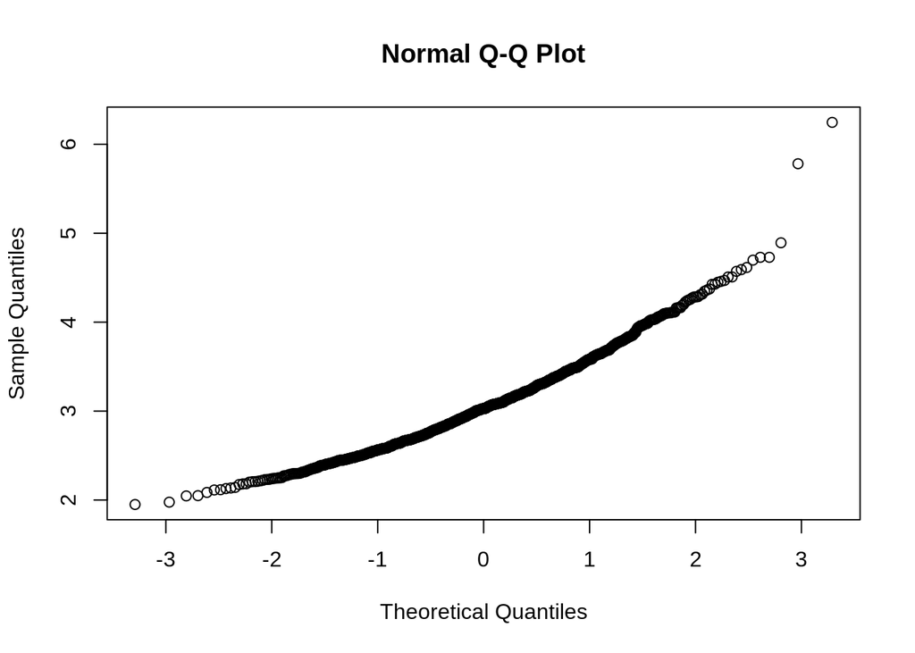

```r
qqnorm(a_chapeau)
```

Plus n est petit (dans la dizaine) et plus on est relativement éloigné d’une répartition normale des estimateurs. Par contre dès que l’on fait grandir n (dans les centaines et plus), on obtient une répartition très rapidement proche d’une loi normale.

On en conclut que les estimateurs suivent asymptotiquement une loi normale.

# Partie 3

## Question 1

Le modèle de la loi $\mathcal{Pa}(\hat{a}_n', 2)$ est un modèle satisfaisant pour les deux cuves 1 et 2.

Pour la cuve 3 :

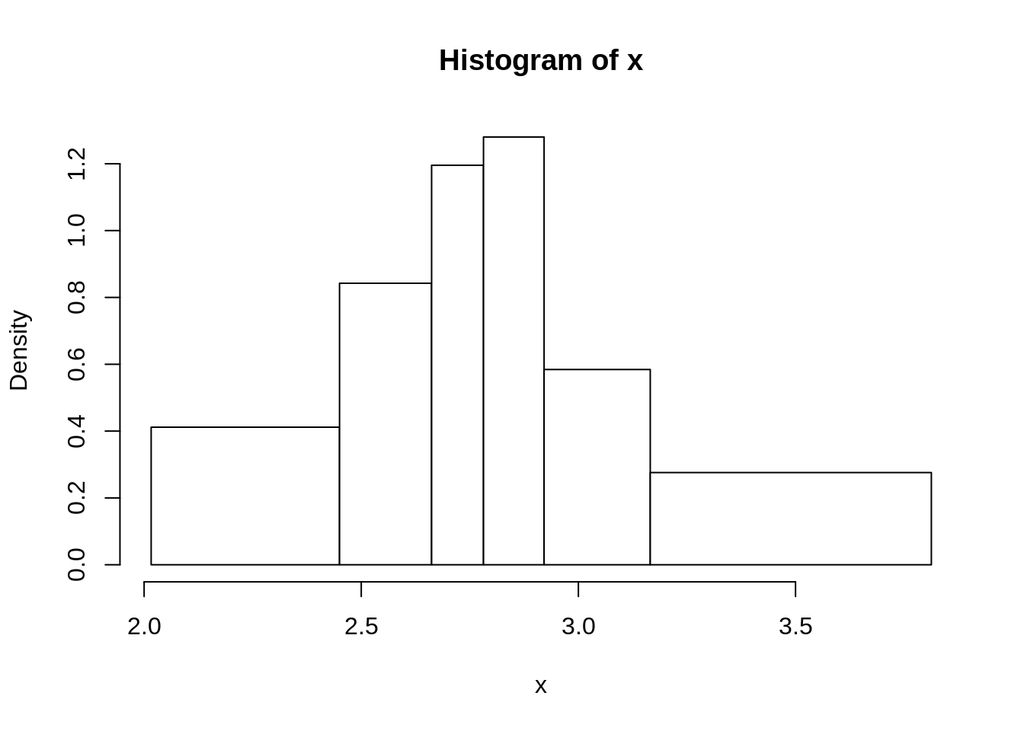

```r
histoeff(cuve3)
```

La forme en cloche de l’histogramme nous permet de choisir soit la loi normale ou la loi $\chi^2$ .

```r
par(mfcol=c(1,2))

#loi normale
qqnorm(cuve3, main="Loi normale")
reg_lin_norm <- lm(sort(cuve3[1:n_3-1])~qnorm(seq(1:(n_3-1))/n_3))
summary(reg_lin_norm)
```

```
##
## Call:
## lm(formula = sort(cuve3[1:n_3 - 1]) ~ qnorm(seq(1:(n_3 - 1))/n_3))
##
## Residuals:
##      Min       1Q   Median       3Q      Max
## -0.12156 -0.04267 -0.01982  0.04760  0.23483
##
## Coefficients:
##                             Estimate Std. Error t value Pr(>|t|)
## (Intercept)                  2.81715    0.01524  184.83   <2e-16 ***
## qnorm(seq(1:(n_3 - 1))/n_3)  0.45728    0.01705   26.82   <2e-16 ***
## ---
## Signif. codes:  0 '***' 0.001 '**' 0.01 '*' 0.05 '.' 0.1 ' ' 1
##
## Residual standard error: 0.0792 on 25 degrees of freedom
## Multiple R-squared:  0.9664, Adjusted R-squared:  0.9651
## F-statistic: 719.5 on 1 and 25 DF,  p-value: < 2.2e-16
```

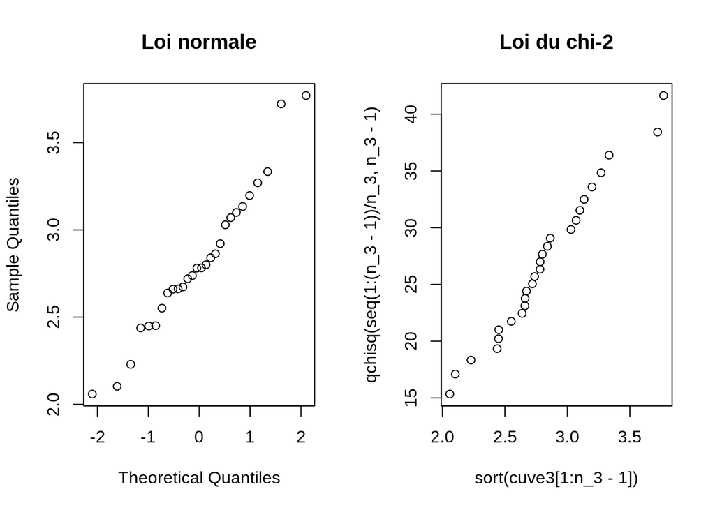

```r
#loi du chi-2
plot(sort(cuve3[1:n_3-1]),qchisq(seq(1:(n_3-1))/n_3, n_3-1),main="Loi du chi-2")
```

```r
reg_lin_norm <- lm(sort(cuve3[1:n_3-1])~qchisq(seq(1:(n_3-1))/n_3, n_3-1))
summary(reg_lin_norm)
```

```
##
## Call:
## lm(formula = sort(cuve3[1:n_3 - 1]) ~ qchisq(seq(1:(n_3 - 1))/n_3,
##     n_3 - 1))
##
## Residuals:
##       Min        1Q    Median        3Q       Max
## -0.099739 -0.045979 -0.002737  0.032197  0.177843
##
## Coefficients:
##                                       Estimate Std. Error t value Pr(>|t|)
## (Intercept)                           1.126694   0.054455   20.69   <2e-16
## qchisq(seq(1:(n_3 - 1))/n_3, n_3 - 1) 0.062918   0.001969   31.95   <2e-16
##
## (Intercept)                           ***
## qchisq(seq(1:(n_3 - 1))/n_3, n_3 - 1) ***
## ---
## Signif. codes:  0 '***' 0.001 '**' 0.01 '*' 0.05 '.' 0.1 ' ' 1
##
## Residual standard error: 0.06683 on 25 degrees of freedom
## Multiple R-squared:  0.9761, Adjusted R-squared:  0.9751
## F-statistic:  1021 on 1 and 25 DF,  p-value: < 2.2e-16
```

D’après les valeurs des paramétres de la regression linéaire, il semble plus probable que les fissures de la cuve 3 suivent une loi $\chi^2_{n-1}$. L’écart min/max ainsi que la médiane des résidus sont nettement plus faibles, et on remarque que $r$ est plus proche de $1$ sur le modèle en $\chi^2_{n-1}$ que sur le modéle de la loi normale.

## Question 2

### Partie -a- :

Soit $X$ la variable modélisant la proportion des defauts des trois cuves. Pour une cuve donnée, et selon les propos du constructeur, on a – $P(X > 5) < 0.05$ ou $P(X < 5) > 0.95$. Il semble donc légitime d’effectuer un test d’hypothèse unilatéral.

On se place du point de vue du constructeur. On pose donc l’hypothèse nulle: H0= “X est inférieur à 5” et l’hypothèse alternative: H1= “X est supérieur à 5”

D’après le constructeur, on peut choisir pour ce test un seuil alpha=0.05 .

Pour les cuves 1 et 2, on réutilise la variable $Y = \ln{\frac{X}{2}}$. Le problème se transforme en :
$$P\left(Y < \ln{\frac{5}{2}}\right) > 0.95$$

Soit $\a_0$ la valeur telle que :
$$P\left(Y_{a_0} < \ln{\frac{5}{2}}\right) = 0.95$$

Alors :

$$a_0 = -\frac{\ln{0.05}}{\ln{\frac{5}{2}}}$$
.

```r
#Calcul de a_0
a_0 = -log(0.05)/log(5/2)
a_0
```

```
## [1] 3.269412
```

Si l’on se base sur les dires du constructeur, les defauts sont censé suivre une loi de paramètre a_0 (si l’on considère qu’elles suivent une loi Pa)

On considére $\alpha$ tel que:
$$\begin{aligned}
\alpha &= \underset{a \geq a_0}{\sup}P\left(\hat{a}_n' \leq l_\alpha\right) \\
&= \underset{a \geq a_0}{\sup}P\left(\sum Y_n \geq \frac{n-1}{l_\alpha}\right) \\
&= \underset{a \geq a_0}{\sup}P\left(2a \sum Y_n \geq \frac{2a(n-1)}{l_\alpha}\right) \\
&= \underset{a \geq a_0}{\sup} 1 - F_{\chi^2_{2n}}\left(\frac{2a(n-1)}{l_\alpha}\right) \\
&= 1 - F_{\chi^2_{2n}}\left(\frac{2a_0(n-1)}{l_\alpha}\right)
\end{aligned}$$

On a ainsi
$$l_\alpha = \frac{2 a_0 (n-1)}{z_{2n, \alpha}}$$
.

On peut donc en déduire la $p$-valeur $\alpha_c$ de ce test:
$$\begin{aligned}
\hat{a}_n' = \frac{2a_0(n-1)}{z_{2n,\alpha_c}} &\Leftrightarrow z_{2n,\alpha_c} = \frac{2a_0(n-1)}{\hat{a}_n'} \\
&\Leftrightarrow \alpha_c = 1 - F_{\chi^2_{2n}} \left(\frac{2a_0(n-1)}{\hat{a}_n'} \right)
\end{aligned}$$

```r
#les estimateurs non biaisés des deux premiéres cuves :
hat_a1_n_p = (n_1 - 1) * hat_a1_n / n_1
hat_a2_n_p = (n_2 - 1) * hat_a2_n / n_2


#Calcul de la p_valeur de la cuve 1
pval_cuve_1 = 1 - pchisq((2*a_0*(n_1-1)) / hat_a1_n_p, 2*n_1)
pval_cuve_1
```

```
## [1] 0.4087746
```

```r
#Calcul de la p_valeur de la cuve 2
pval_cuve_2 = 1 - pchisq((2*a_0*(n_2-1)) / hat_a2_n_p, 2*n_2)
pval_cuve_2
```

```
## [1] 0.8989361
```

Les $p$-valeurs pour la cuve 1 et la cuve 2 sont respectivement : 0.40 et 0.89 . On en conclut qu’il est alors très risqué de rejeter H0 dans les deux cas et d’autant plus pour la cuve 2. En effet, quelqu’un qui affirmera que H0 est fausse à cause des données de la cuve 2 aura plus de 89% de chances de se tromper.

Pour la troisième cuve, il suffit d’effectuer un test de Student sur $\sqrt(Y)$.

```r
t.test(sqrt(log(cuve3/2)), alterative="more", mu=sqrt(a_0))
```

```
##
##  One Sample t-test
##
## data:  sqrt(log(cuve3/2))
## t = -45.29, df = 27, p-value < 2.2e-16
## alternative hypothesis: true mean is not equal to 1.808152
## 95 percent confidence interval:
##  0.5028236 0.6159722
## sample estimates:
## mean of x
## 0.5593979
```

Avec une p-valeur de 2.2e-16 , il est logique de douter de l’affirmation du constructeur. Il est même très difficile de croire en H0. Pour ne pas rejeter H0, il faudrait vouloir une chance de se tromper inférieure à 2e-16.

### Partie -b- :

Le fonctionnement de la machine B nous oblige à effectuer un test de proportion pour les trois cuves :

```r
binom.test(length(cuve1[cuve1 > 5]), length(cuve1), p=0.05, alternative = "less")
```

```
##
##  Exact binomial test
##
## data:  length(cuve1[cuve1 > 5]) and length(cuve1)
## number of successes = 2, number of trials = 30, p-value = 0.8122
## alternative hypothesis: true probability of success is less than 0.05
## 95 percent confidence interval:
##  0.000000 0.195326
## sample estimates:
## probability of success
##             0.06666667
```

```r
binom.test(length(cuve2[cuve2 > 5]), length(cuve2), p=0.05, alternative = "less")
```

```
##
##  Exact binomial test
##
## data:  length(cuve2[cuve2 > 5]) and length(cuve2)
## number of successes = 1, number of trials = 25, p-value = 0.6424
## alternative hypothesis: true probability of success is less than 0.05
## 95 percent confidence interval:
##  0.0000000 0.1761207
## sample estimates:
## probability of success
##                   0.04
```

```r
binom.test(length(cuve3[cuve3 > 5]), length(cuve3), p=0.05, alternative = "less")
```

```
##
##  Exact binomial test
##
## data:  length(cuve3[cuve3 > 5]) and length(cuve3)
## number of successes = 0, number of trials = 28, p-value = 0.2378
## alternative hypothesis: true probability of success is less than 0.05
## 95 percent confidence interval:
##  0.0000000 0.1014657
## sample estimates:
## probability of success
##                      0
```

On remarque que les p-valeurs des trois cuves sont respectivement : 0.81, 0.64, et 0.23. Cette fois ci, les résultats montrent que rien ne nous indique que les constructeur ment, et cela meme pour la cuve 3: on ne peut affirmer que H0 fausse pour la cuve 3 qu’en prenant un risque supérieur à 23% de se tromper.

Avec seulement l’appareil B, on ne peut conclure qu’à la véracité de H0 si l’on ne veut pas prendre de risque inconsidéré.